# task5

### Практическое задане 5

##### Плискин Александр

```python
import numpy as np
import matplotlib.pyplot as plt

from scipy import optimize

import math
import subprocess
```

```python
%matplotlib inline
```

### Utils

```python
def run_orca(f):
    cmd = '/home/shad/progs/bin/orca ' + f
    p = subprocess.Popen(cmd, shell=True, stdout=subprocess.PIPE, stderr=subprocess.PIPE)
    out = p.communicate()[0]
    lines = out.splitlines()
    res = 'inf'
    for l in lines:
        if 'FINAL SINGLE POINT ENERGY' in l:
            res = l.split()[4]
    return float(res)
```

```python
def dep_plot(x,y,x_lim1,x_lim2):
    x_o = x
    y_o = y
    # function is  f(x)=k(b-x)^2 + a
    fitfunc = lambda p, x: p[0]*pow(p[1]-x,2) + p[2] # Target function
    errfunc = lambda p, x, y: fitfunc(p, x) - y # Error function
    p0 = [1,1, -79] # Initial guess for the parameters

    p1, success = optimize.leastsq(errfunc, p0[:], args=(x_o, y_o))
    print 'Optimized params:', p1

    plt.plot(x_o, y_o, 'ro', x_o,fitfunc(p1,x_o),'r-',c='blue',alpha=0.5)
    plt.xlim(x_lim1,x_lim2)
    plt.show()
```

```python
inp_default = '''!HF RHF 6-31G
* int 0 1
C 0 0 0 0 0 0
C 1 0 0 1.52986 0 0
H 1 2 0 1.08439 111.200 0
H 1 2 3 1.08439 111.200 120
H 1 2 3 1.08439 111.200 -120
H 2 1 3 1.08439 111.200 180
H 2 1 5 1.08439 111.200 120
H 2 1 5 1.08439 111.200 -120
*
'''
```

```python
inp = '''!HF RHF 6-31G
* int 0 1
C 0 0 0 0 0 0
C 1 0 0 {length} 0 0
H 1 2 0 1.08439 {angle} 0
H 1 2 3 1.08439 {angle} 120
H 1 2 3 1.08439 {angle} -120
H 2 1 3 1.08439 {angle} {torsion1}
H 2 1 5 1.08439 {angle} {torsion2}
H 2 1 5 1.08439 {angle} {torsion3}
*
'''
```

### 1. Длины связей

Текущая длина связи "С-С" 1.52986.  
Генерируем 20 возможных длин связи C-C с шагом в 0.02 ангстрема.

```python
bond = [1.52986+i*0.02 for i in range(-10, 10)]
energy = []
for i in range(20):
    s = inp.format(length = bond[i], angle = 111.200, torsion1 = 180, torsion2 = 120, torsion3 = -120)
    name = 'orca_CC{}.inp'.format(i)
    with open(name, 'w') as f:
        f.write(s)
    energy.append(run_orca(name))
```

Строим график зависимости энергии молекулы от длины связи C-C:

```
Optimized params: [  0.66824849   1.55389247 -79.08233321]
```

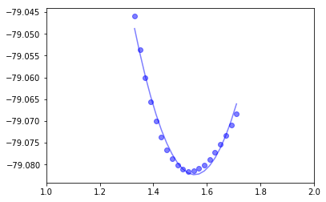

```
1.52986
```

```python
dep_plot(bond, energy, 1, 2)
print bond[np.argmin(energy)]
```

Оптимальным значением длины связи является изначально заданный.  
С его увеличением или уменьшением энергия только увеличивается.

### 2. Валентные углы

Генерация 20 файлов с молекулой этана с различными величинами угла H-C-С (109.2-113.2)

```python
angle = [i for i in np.arange(109.2, 113.2, 0.2)]
energy = []
for i in range(20):
    s = inp.format(length = 1.52986, angle = angle[i], torsion1 = 180, torsion2 = 120, torsion3 = -120)
    name = 'orca_HCC{}.inp'.format(i)
    with open(name, 'w') as f:
        f.write(s)
    energy.append(run_orca(name))
```

Строим график зависимости энергии молекулы от угла H-C-С:

```
Optimized params: [ 3.30818768e-04  1.12271979e+02 -7.90819115e+01]
```

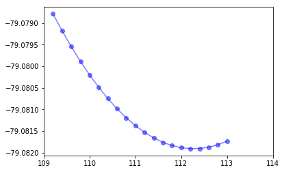

```
112.20000000000005
```

```python
dep_plot(angle, energy, 109, 114)
print angle[np.argmin(energy)]
```

#### Сравнение полученных констант с данными из статьи о GAFF:

##### Из статьи:

В статье вычисления делаются на основе методов молекулярной динамики, а расчёты в ORCA - методами квантовой химии.

Эмпирическое уравнение для связей С-С

$ ln(Kr)=−4.9575⋅r+7.8187 $

Оптимальная длиная связи (по статье):

$ r=1.526 $

Тут :

$ K_{r} = 0.66824639Eh * 627,51Ккал/моль = 419.331Ккал/моль $

В статье о GAFF говориться, что k ~ 50 ккал/мольxрад^2, величина b явно не указана явно.

### 3. Торсионные углы

Генерация 30 файлов с молекулой этана с различными величинами торсионного угла C-С (-180-180 c шагом 12):

```python
torsion = [i for i in range(-180, 180, 12)]
energy = []
for i in range(30):
    s = inp.format(length = 1.52986, angle = 111.200, torsion1 = torsion[i], torsion2 = torsion[i] - 60,
                   torsion3 = torsion[i] + 60)
    name = 'orca_torsionCC{}.inp'.format(i)
    with open(name, 'w') as f:
        f.write(s)
    energy.append(run_orca(name))
```

```
Optimized params: [ 1.10084875e-08 -9.78107531e+01 -7.90827505e+01]
```

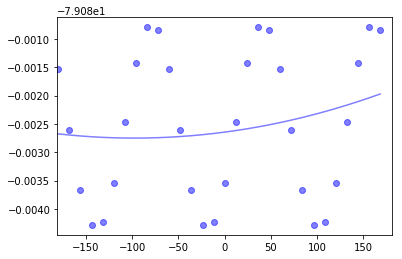

```
-144
```

```python
dep_plot(torsion, energy, -181, 181)
print torsion[np.argmin(energy)]
```

У функции три минимума.  
Квадратичной функцией aппроксимируется плохо.  
Поэтому попробуем циклическую функцию:  
$ f(x) = a * sin(b * x+c) + d $

```
Optimized params: [ 1.81236461e-03  9.94840542e-01 -7.79514494e+01 -7.90825389e+01]
```

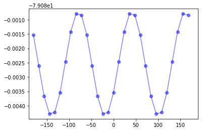

```python
fitfunc = lambda p, x: p[0]*np.sin(p[1]*x+p[2]) + p[3]
errfunc = lambda p, x, y: fitfunc(p, x) - y
p0 = [1,1, -79,1]

torsion = np.array(torsion)

p1, success = optimize.leastsq(errfunc, p0[:], args=(torsion, np.array(energy)))
print 'Optimized params:', p1

plt.plot(torsion, energy, 'ro', torsion ,fitfunc(p1,torsion),'r-',c='blue',alpha=0.5)
plt.xlim(-190,190)
plt.show()
```

### 4. Длины связей с увеличинным шагом

Текущая длина связи "С-С" 1.52986.  
Генерируем 20 возможных длин связи C-C с шагом в 0.1 ангстрема.

```python
bond = [1.52986+i*.1 for i in range(-10, 10)]
energy = []
for i in range(20):
    s = inp.format(length = bond[i], angle = 111.200, torsion1 = 180, torsion2 = 120, torsion3 = -120)
    name = 'orca_CC{}.inp'.format(i)
    with open(name, 'w') as f:
        f.write(s)
    energy.append(run_orca(name))
```

Строим график зависимости энергии молекулы от длины связи C-C:

```
Optimized params: [  2.95586936   1.75910801 -79.56411646]
```

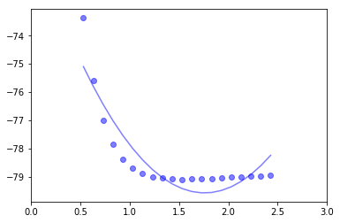

```
1.52986
```

```python
dep_plot(bond, energy, 0, 3)
print bond[np.argmin(energy)]
```

Квадратичной функцией aппроксимируется плохо.  
Поэтому попробуем функцию:  
$ f(x)=(\dfrac{a}{x})^c + b $

```
Optimized params: [  0.89696622   3.37808767 -79.15695836]
```

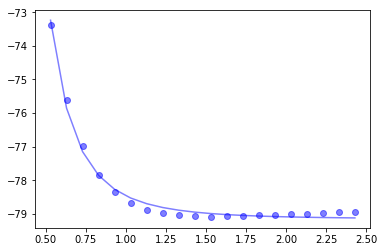

```python
fitfunc = lambda p, x: (p[0]/x)**p[1] + p[2]
errfunc = lambda p, x, y: fitfunc(p, x) - y

p0 = [1, 4, -79]
p1, success = optimize.leastsq(errfunc, p0[:], args=(bond, energy))
print 'Optimized params:', p1

plt.plot(bond, energy, 'ro', bond, fitfunc(p1, bond), 'r-', c='blue', alpha=0.5)
plt.show()
```